# PPOL 563 - Problem Set 3

Alex Lundry

2022-03-02

## Problem Set 3 - PPOL 563

**Question 1**: Reproduce the map plot below, which shows median household income from the 2016-2020 ACS in Virginia by county. BUT, the counties that comprise Northern Virginia are grouped together into one distinct region, while the rest of the state is represented by individual counties. The variable shown for those Northern Virginia counties is the **median** of the median household incomes for that group of counties. I used the definition of Northern Virginia from [here](https://en.wikipedia.org/wiki/Northern_Virginia). A few things to take note of:

- label for NoVa area
- the label formatting on the legend
- the color scale

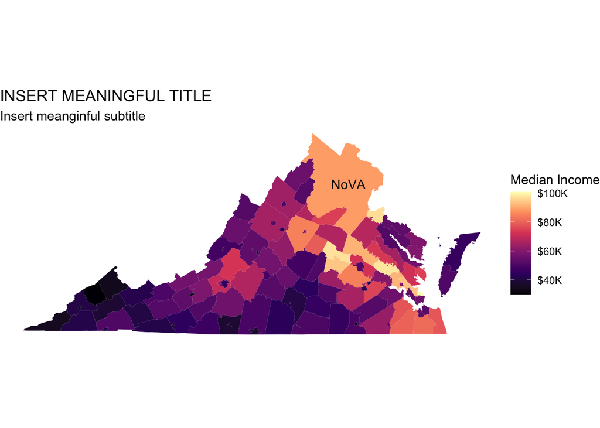

**Question 2**: Reproduce the hexbin map below, which displays results from the 2016 presidential election by state, including the percent margin and the winner of each state. Things to take note of:

- the type of cartogram
- the coloring of the hexbin
- the coloring of the borders

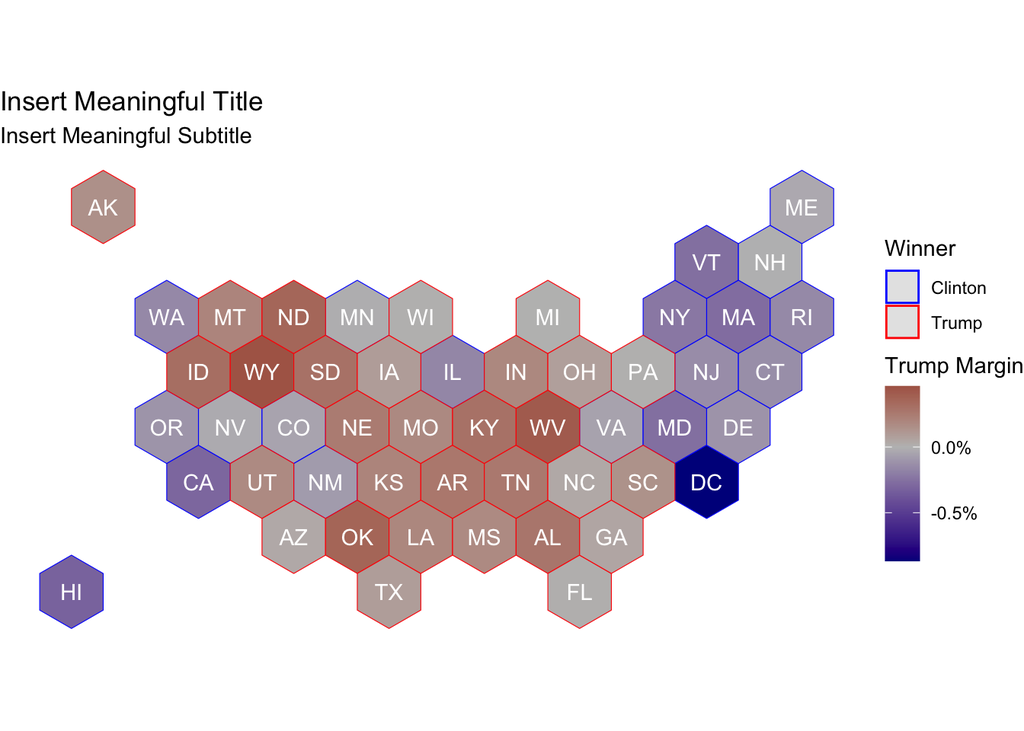

For the final question of the problem set, you will be required to make your own visualization without any reference viz to guide you.

**Question 3**: Using `gun_background_checks.csv`, create a choropleth map of any element from the dataset. The data is a file of Firearm Background Check data collected by the FBI. You can find details on the data [here](https://github.com/BuzzFeedNews/nics-firearm-background-checks)

*Your plot should have a legend (if necessary), descriptive title and subtitle, and all plot elements should be human readable (no overlapping text, no acronyms unless they are defined, no underscores). Scales should make sense and be rounded to 2 digits or less (if applicable). You may NOT use the default Mercator projection*